# Programming Assignment 1

Joseph Walker

February 10, 2017

## Programming Assignment 1

Use the tab-delimited gem data set ddset.tsv posted in the Files section under Assignment 1 to do the following:

- Write an RMarkdown file and use it to generate a knitted HTML file that includes a bar plot of the count of observations in the data set showing price ranking by cut, where price ranking is defined as price:
  - up to the 15th percentile: Lowest
  - 16th to the 30th percentile: Moderate
  - 31st to the 75th percentile: Higher
  - above 75th percentile: Expensive

### Hand in three files:

1. Your RMarkdown file: asn1_firstname_lastname.Rmd
2. Knitted HTML with source: asn1_firstname_lastname_with_source.html (with source code, i.e. chunk option echo = TRUE)
3. Knitted HTML with no source: asn1_firstname_lastname.html (with source code, i.e. chunk option echo = FALSE)

### Mandatory Specifications

1. Assume ddset.tsv is on the same directory as your .Rmd file. Your HTML file results should be 100% reproducible: I should be able to Knit it to HTML without modification
2. Include in your results the complete problem description text for Programming Assignment 1 above
3. In the YAML section of your .Rmd file, include title “Programming Assignment 1,” author (your name), and date. Of course, output should be HTML
4. Use base R and ggplot2 only in your solution. Use no other packages except ggplot2 (do not use dplyr!)
5. Follow the style guidelines described by Hadley Wickham in this R style guide
6. Include a short (no more than one paragraph) description of your approach to solving the problem at the end of your HTML document

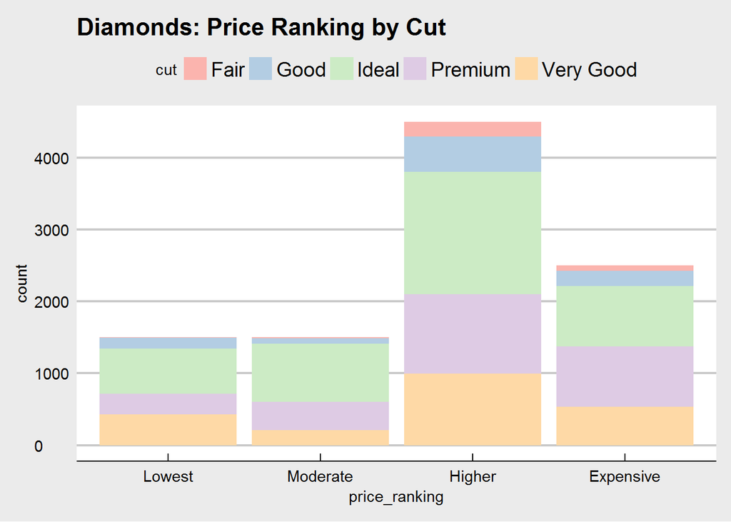

1. The first step in this assignment requires importing the data set `ddset.tsv`. I have named the data set `diamonds`.
2. Next, I use the `quantile` function on the price variable to determine the cut off values for the specified categories we want to create in the next step.
3. I then use the `cut` function to split the price column into categories or bins based on the price groups we are interested in. I assign these values to a new variable: `price_ranking` into our existing data frame `diamonds`.
4. Finally, I use ggplot to create a stacked bar chart displaying the count of each diamond cut based on its price_ranking.